# HNB DigiMedia Map 5: Institutional Attention Gap

Testing Whether Official Communication Achieves Visibility Proportional to Policy Relevance

Author

HNB DigiMedia Project

Published

January 28, 2026

# 1 Introduction

This document presents **Map 5: Institutional Attention Gap Analysis**, the core empirical test of the HNB DigiMedia project. The central research question is:

> **Does official HNB communication achieve visibility proportional to its policy relevance in the Croatian digital media ecosystem?**

## 1.1 Theoretical Motivation

The literature review establishes that central bank communication works primarily through managing expectations (Woodford 2001). However, research documents a persistent gap between institutional communication efforts and public reception:

1. **Rational inattention:** Sims argues economic agents have finite information processing capacity, explaining why markets attend to every nuance while ordinary people react sluggishly
2. **Public communication failure:** Blinder’s prediction that central bank public communication would “for the most part fail” has proven “more correct than incorrect”
3. **Intermediation dominance:** Coibion et al. found that reading FOMC statements has about the same effect as simply being told the inflation target, while news articles had half that effect

For Croatia specifically, the challenge is compounded by:

- Resource constraints of smaller central banks
- Bilingual communication requirements
- Transition from independent monetary policy to Eurosystem membership
- Virtual absence of academic research on HNB communication

## 1.2 Analytical Framework

The **Institutional Attention Gap** is operationalized as the difference between:

- **Policy relevance share:** The proportion of authoritative monetary policy information that originates from institutional sources (HNB, regulators, government)
- **Attention share:** The proportion of total public attention (REACH) captured by institutional sources

A negative gap indicates institutional sources are underperforming relative to their policy relevance, with media intermediation capturing disproportionate attention.

```r
hnb <- readRDS("C:/Users/lsikic/Dropbox/hnb.rds")
setDT(hnb)

hnb[, date := as.Date(DATE)]
hnb[, year := year(date)]
hnb[, month := month(date)]
hnb[, week := isoweek(date)]

hnb[, period := fcase(
  date < as.Date("2023-01-01"), "ERM II",
  default = "Euro Era"
)]
hnb[, period := factor(period, levels = c("ERM II", "Euro Era"))]

n_articles <- nrow(hnb)
cat("Data loaded:", n_articles, "articles\n")
```

```
Data loaded: 19128 articles
```

```r
# =============================================================================
# ACTOR CLASSIFICATION - SYNCHRONIZED WITH MAPS 1-4
# =============================================================================

manual_overrides <- list(
  "HNB Official" = c(
    "hnb.hr", "hrvatska narodna banka",
    "hrvatska narodna banka / croatian national bank"
  ),
  "Financial Regulators" = c(
    "hanfa.hr", "hanfa", "hrvatska agencija za nadzor financijskih usluga",
    "fina.hr", "fina", "financijska agencija"
  ),
  "Government" = c(
    "gov.hr", "vlada", "vlada republike hrvatske",
    "ministarstvo financija", "sabor.hr"
  ),
  "Financial Media" = c(
    "poslovni.hr", "poslovni dnevnik", "seebiz.eu", "seebiz",
    "lider.media", "lidermedia.hr", "lider", "bloombergadria.com",
    "bloomberg adria", "hrportfolio.hr", "privredni.hr"
  ),
  "Commercial Banks" = c(
    "zaba.hr", "zagrebačka banka", "pbz.hr", "privredna banka zagreb",
    "erste.hr", "erste banka", "hpb.hr", "hrvatska poštanska banka",
    "otp banka", "raiffeisen", "addiko"
  ),
  "Academic/Expert" = c(
    "eizg.hr", "ekonomski institut zagreb", "ijf.hr",
    "institut za javne financije", "ekonomski fakultet"
  )
)

general_media_sources <- c(
  "index.hr", "index", "jutarnji.hr", "jutarnji", "jutarnji list",
  "vecernji.hr", "vecernji", "večernji list",
  "24sata.hr", "24sata", "slobodnadalmacija.hr", "slobodna dalmacija",
  "novilist.hr", "novi list", "dnevnik.hr", "dnevnik",
  "tportal.hr", "tportal", "telegram.hr", "telegram",
  "net.hr", "rtl.hr", "rtl", "hrt.hr", "hrt",
  "n1info.hr", "n1info.com", "n1", "nacional.hr", "nacional",
  "direktno.hr", "direktno", "dnevno.hr", "dnevno"
)

classify_actor_hnb <- function(from_val, url_val = NA) {
  from_lower <- tolower(trimws(as.character(from_val)))
  url_lower <- tolower(ifelse(is.na(url_val), "", as.character(url_val)))
  combined <- paste(from_lower, url_lower)

  match_any <- function(patterns, text, fixed = TRUE) {
    any(sapply(patterns, function(p) grepl(p, text, fixed = fixed)))
  }

  for (actor_type in names(manual_overrides)) {
    if (match_any(manual_overrides[[actor_type]], from_lower)) {
      return(actor_type)
    }
  }

  if (grepl("hnb\\.hr", url_lower) || grepl("hnb\\.hr", from_lower)) {
    return("HNB Official")
  }

  if (grepl("hanfa|fina\\.hr", combined)) {
    return("Financial Regulators")
  }

  if (grepl("gov\\.hr|vlada|ministarstvo", combined)) {
    return("Government")
  }

  bank_patterns <- c("banka", "bank", "zaba", "pbz", "erste", "hpb",
                     "otp", "raiffeisen", "addiko", "sberbank")
  if (match_any(bank_patterns, from_lower)) {
    if (!grepl("narodna|hnb|central", from_lower)) {
      return("Commercial Banks")
    }
  }

  financial_media_patterns <- c(
    "poslovni", "seebiz", "lider", "bloomberg", "portfolio",
    "privredni", "finance", "ekonom", "business", "capital"
  )
  if (match_any(financial_media_patterns, from_lower)) {
    return("Financial Media")
  }

  if (match_any(general_media_sources, from_lower)) {
    return("General Media")
  }

  news_patterns <- c("portal", "vijesti", "news", "info", "dnevni",
                     "radio", "tv", ".hr")
  if (match_any(news_patterns, from_lower)) {
    return("General Media")
  }

  return("Other")
}

hnb[, ACTOR_TYPE := mapply(classify_actor_hnb, FROM, URL)]

# Create institutional classification
hnb[, INSTITUTIONAL := ACTOR_TYPE %in% c("HNB Official", "Financial Regulators", "Government")]
hnb[, INST_CATEGORY := ifelse(INSTITUTIONAL, "Institutional", "Non-Institutional")]
```

# 2 Analysis 5.1: The Attention Gap Baseline

## 2.1 Core Metrics

```r
# Calculate baseline metrics
total_articles <- nrow(hnb)
total_reach <- sum(hnb$REACH, na.rm = TRUE)

# Institutional vs Non-institutional breakdown
inst_summary <- hnb[, .(
  Articles = .N,
  Total_REACH = sum(REACH, na.rm = TRUE),
  Mean_REACH = mean(REACH, na.rm = TRUE),
  Median_REACH = median(REACH, na.rm = TRUE),
  Sources = uniqueN(FROM)
), by = INST_CATEGORY]

inst_summary[, `:=`(
  Article_Share = Articles / sum(Articles) * 100,
  REACH_Share = Total_REACH / sum(Total_REACH) * 100
)]

inst_summary[, Attention_Gap := REACH_Share - Article_Share]
inst_summary[, Efficiency := REACH_Share / Article_Share]

# Display
inst_summary %>%
  mutate(
    Articles = format(Articles, big.mark = ","),
    Total_REACH = format(Total_REACH, big.mark = ","),
    Mean_REACH = format(round(Mean_REACH, 0), big.mark = ","),
    Median_REACH = format(round(Median_REACH, 0), big.mark = ","),
    Article_Share = sprintf("%.1f%%", Article_Share),
    REACH_Share = sprintf("%.1f%%", REACH_Share),
    Attention_Gap = sprintf("%+.1f pp", Attention_Gap),
    Efficiency = sprintf("%.2fx", Efficiency)
  ) %>%
  kable(col.names = c("Category", "Articles", "Total REACH", "Mean REACH", "Median REACH",
                      "Sources", "Article Share", "REACH Share", "Attention Gap", "Efficiency")) %>%
  kable_styling(bootstrap_options = c("striped", "hover"), full_width = FALSE)
```

| Category | Articles | Total REACH | Mean REACH | Median REACH | Sources | Article Share | REACH Share | Attention Gap | Efficiency |
| --- | --- | --- | --- | --- | --- | --- | --- | --- | --- |
| Non-Institutional | 18,244 | 47,572,372 | 2,634 | 495 | 878 | 95.4% | 90.9% | -4.5 pp | 0.95x |
| Institutional | 884 | 4,780,494 | 5,445 | 349 | 96 | 4.6% | 9.1% | +4.5 pp | 1.98x |

## 2.2 Attention Gap Visualization

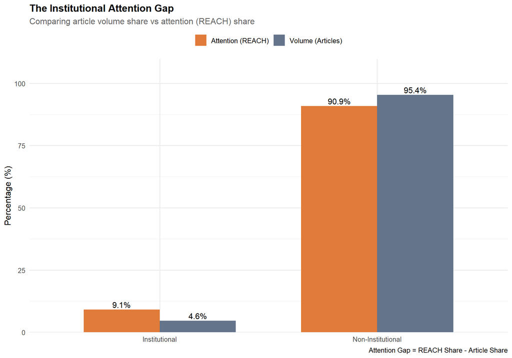

```r
inst_long <- inst_summary %>%
  select(INST_CATEGORY, Article_Share, REACH_Share) %>%
  pivot_longer(cols = c(Article_Share, REACH_Share),
               names_to = "Metric", values_to = "Percentage") %>%
  mutate(Metric = ifelse(Metric == "Article_Share", "Volume (Articles)", "Attention (REACH)"))

ggplot(inst_long, aes(x = INST_CATEGORY, y = Percentage, fill = Metric)) +
  geom_col(position = "dodge", width = 0.7) +
  geom_text(aes(label = sprintf("%.1f%%", Percentage)),
            position = position_dodge(width = 0.7), vjust = -0.3, size = 4) +
  scale_fill_manual(values = c("Volume (Articles)" = "#64748b", "Attention (REACH)" = "#e07b39")) +
  scale_y_continuous(expand = expansion(mult = c(0, 0.15))) +
  labs(
    title = "The Institutional Attention Gap",
    subtitle = "Comparing article volume share vs attention (REACH) share",
    x = NULL,
    y = "Percentage (%)",
    fill = NULL,
    caption = "Attention Gap = REACH Share - Article Share"
  ) +
  theme(legend.position = "top")
```

## 2.3 Statistical Test: Institutional Attention Disadvantage

We test whether institutional sources have significantly lower REACH than non-institutional sources using the Wilcoxon rank-sum test (appropriate for non-normal distributions).

```r
# Extract REACH vectors
reach_institutional <- hnb[INSTITUTIONAL == TRUE, REACH]
reach_non_institutional <- hnb[INSTITUTIONAL == FALSE, REACH]

# Wilcoxon rank-sum test
wilcox_result <- wilcox.test(reach_institutional, reach_non_institutional,
                              alternative = "two.sided")

# Effect size (rank-biserial correlation)
n1 <- length(reach_institutional)
n2 <- length(reach_non_institutional)
U <- wilcox_result$statistic
effect_size <- 1 - (2 * U) / (n1 * n2)

cat("Wilcoxon Rank-Sum Test Results\n")
```

```
Wilcoxon Rank-Sum Test Results
```

```r
cat("==============================\n")
cat("W statistic:", format(wilcox_result$statistic, big.mark = ","), "\n")
```

```
W statistic: 8,011,646
```

```r
cat("p-value:", format.pval(wilcox_result$p.value, digits = 4), "\n")
```

```
p-value: 0.5945
```

```r
cat("\nSample sizes:\n")
```

```
Sample sizes:
```

```r
cat("  Institutional:", format(n1, big.mark = ","), "articles\n")
```

```
  Institutional: 884 articles
```

```r
cat("  Non-institutional:", format(n2, big.mark = ","), "articles\n")
```

```
  Non-institutional: 18,244 articles
```

```r
cat("\nMean REACH:\n")
```

```
Mean REACH:
```

```r
cat("  Institutional:", format(round(mean(reach_institutional), 0), big.mark = ","), "\n")
```

```
  Institutional: NA
```

```r
cat("  Non-institutional:", format(round(mean(reach_non_institutional), 0), big.mark = ","), "\n")
```

```
  Non-institutional: NA
```

```r
cat("\nEffect size (rank-biserial r):", round(effect_size, 3), "\n")
```

```
Effect size (rank-biserial r): 0.006
```

## 2.4 REACH Distribution Comparison

[figure not shown]

```r
ggplot(hnb[REACH > 0 & REACH < quantile(REACH, 0.99, na.rm = TRUE)],
       aes(x = REACH, fill = INST_CATEGORY)) +
  geom_density(alpha = 0.6) +
  geom_vline(aes(xintercept = mean(reach_institutional)),
             color = "#1a3c5a", linetype = "dashed", linewidth = 1) +
  geom_vline(aes(xintercept = mean(reach_non_institutional)),
             color = "#e07b39", linetype = "dashed", linewidth = 1) +
  scale_x_log10(labels = comma) +
  scale_fill_manual(values = institutional_colors) +
  labs(
    title = "REACH Distribution: Institutional vs Non-Institutional",
    subtitle = "Log scale, dashed lines show means",
    x = "REACH (log scale)",
    y = "Density",
    fill = "Category"
  ) +
  theme(legend.position = "top")
```

# 3 Analysis 5.2: Actor-Level Decomposition

## 3.1 Detailed Actor Metrics

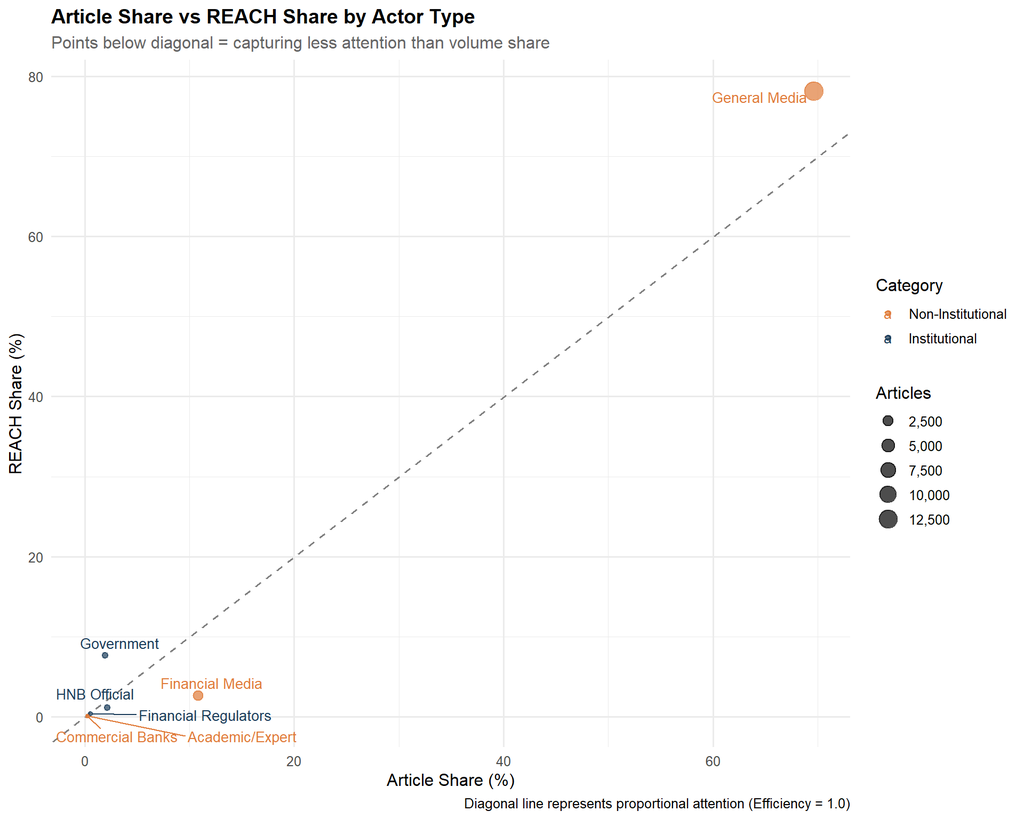

```r
actor_summary <- hnb[, .(
  Articles = .N,
  Total_REACH = sum(REACH, na.rm = TRUE),
  Mean_REACH = mean(REACH, na.rm = TRUE),
  Median_REACH = median(REACH, na.rm = TRUE),
  Sources = uniqueN(FROM),
  Institutional = first(INSTITUTIONAL)
), by = ACTOR_TYPE]

actor_summary[, `:=`(
  Article_Share = Articles / sum(Articles) * 100,
  REACH_Share = Total_REACH / sum(Total_REACH) * 100
)]

actor_summary[, `:=`(
  Attention_Gap = REACH_Share - Article_Share,
  Efficiency = REACH_Share / Article_Share
)]

# Visualize
actor_summary_plot <- actor_summary[ACTOR_TYPE != "Other"]

ggplot(actor_summary_plot, aes(x = Article_Share, y = REACH_Share, color = Institutional)) +
  geom_abline(slope = 1, intercept = 0, linetype = "dashed", color = "gray50") +
  geom_point(aes(size = Articles), alpha = 0.7) +
  geom_text_repel(aes(label = ACTOR_TYPE), size = 3.5, max.overlaps = 15) +
  scale_color_manual(values = c("TRUE" = "#1a3c5a", "FALSE" = "#e07b39"),
                     labels = c("TRUE" = "Institutional", "FALSE" = "Non-Institutional")) +
  scale_size_continuous(labels = comma) +
  labs(
    title = "Article Share vs REACH Share by Actor Type",
    subtitle = "Points below diagonal = capturing less attention than volume share",
    x = "Article Share (%)",
    y = "REACH Share (%)",
    color = "Category",
    size = "Articles",
    caption = "Diagonal line represents proportional attention (Efficiency = 1.0)"
  ) +
  theme(legend.position = "right")
```

## 3.2 Actor Summary Table

```r
actor_summary[order(-REACH_Share)] %>%
  mutate(
    Articles = format(Articles, big.mark = ","),
    Total_REACH = format(Total_REACH, big.mark = ","),
    Mean_REACH = format(round(Mean_REACH, 0), big.mark = ","),
    Article_Share = sprintf("%.1f%%", Article_Share),
    REACH_Share = sprintf("%.1f%%", REACH_Share),
    Attention_Gap = sprintf("%+.1f pp", Attention_Gap),
    Efficiency = sprintf("%.2fx", Efficiency),
    Institutional = ifelse(Institutional, "Yes", "No")
  ) %>%
  select(ACTOR_TYPE, Institutional, Articles, Article_Share, REACH_Share,
         Attention_Gap, Efficiency, Mean_REACH) %>%
  kable(col.names = c("Actor Type", "Institutional", "Articles", "Article Share",
                      "REACH Share", "Attention Gap", "Efficiency", "Mean REACH")) %>%
  kable_styling(bootstrap_options = c("striped", "hover"), full_width = FALSE)
```

| Actor Type | Institutional | Articles | Article Share | REACH Share | Attention Gap | Efficiency | Mean REACH |
| --- | --- | --- | --- | --- | --- | --- | --- |
| General Media | No | 13,319 | 69.6% | 78.2% | +8.5 pp | 1.12x | 3,091 |
| Other | No | 2,752 | 14.4% | 9.9% | -4.5 pp | 0.69x | 1,955 |
| Government | Yes | 371 | 1.9% | 7.7% | +5.7 pp | 3.96x | 10,864 |
| Financial Media | No | 2,069 | 10.8% | 2.7% | -8.2 pp | 0.25x | 674 |
| HNB Official | Yes | 415 | 2.2% | 1.1% | -1.1 pp | 0.50x | 1,380 |
| Financial Regulators | Yes | 98 | 0.5% | 0.4% | -0.1 pp | 0.72x | 1,995 |
| Academic/Expert | No | 53 | 0.3% | 0.1% | -0.2 pp | 0.29x | 803 |
| Commercial Banks | No | 51 | 0.3% | 0.1% | -0.2 pp | 0.25x | 711 |

## 3.3 HNB Official Position Analysis

```r
# HNB specific metrics
hnb_official <- hnb[ACTOR_TYPE == "HNB Official"]
hnb_stats <- actor_summary[ACTOR_TYPE == "HNB Official"]

# Rank calculations
article_rank <- actor_summary[order(-Articles), which(ACTOR_TYPE == "HNB Official")]
reach_rank <- actor_summary[order(-Total_REACH), which(ACTOR_TYPE == "HNB Official")]

cat("HNB Official Communication Analysis\n")
```

```
HNB Official Communication Analysis
```

```r
cat("====================================\n")
cat("Total articles:", format(hnb_stats$Articles, big.mark = ","), "\n")
```

```
Total articles: 415
```

```r
cat("Article share:", sprintf("%.2f%%", hnb_stats$Article_Share), "\n")
```

```
Article share: 2.17%
```

```r
cat("REACH share:", sprintf("%.2f%%", hnb_stats$REACH_Share), "\n")
```

```
REACH share: 1.08%
```

```r
cat("Attention gap:", sprintf("%+.2f pp", hnb_stats$Attention_Gap), "\n")
```

```
Attention gap: -1.09 pp
```

```r
cat("Efficiency:", sprintf("%.2fx", hnb_stats$Efficiency), "\n")
```

```
Efficiency: 0.50x
```

```r
cat("\nRankings (among", nrow(actor_summary), "actor types):\n")
```

```
Rankings (among 8 actor types):
```

```r
cat("  By article volume: #", article_rank, "\n")
```

```
  By article volume: # 4
```

```r
cat("  By total REACH: #", reach_rank, "\n")
```

```
  By total REACH: # 5
```

```r
cat("\nMean REACH:", format(round(hnb_stats$Mean_REACH, 0), big.mark = ","), "\n")
```

```
Mean REACH: 1,380
```

```r
cat("Median REACH:", format(round(hnb_stats$Median_REACH, 0), big.mark = ","), "\n")
```

```
Median REACH: 141
```

# 4 Analysis 5.3: Temporal Evolution of Attention Gap

## 4.1 Monthly Attention Gap Trends

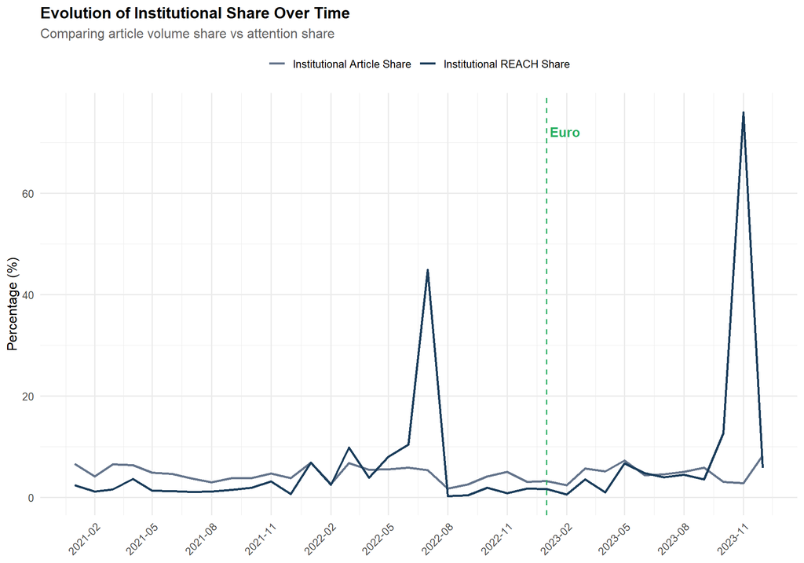

```r
monthly_inst <- hnb[, .(
  Articles = .N,
  Total_REACH = sum(REACH, na.rm = TRUE),
  Inst_Articles = sum(INSTITUTIONAL),
  Inst_REACH = sum(REACH[INSTITUTIONAL], na.rm = TRUE)
), by = .(year, month)]

monthly_inst[, `:=`(
  date_month = as.Date(paste(year, month, "01", sep = "-")),
  Inst_Article_Share = Inst_Articles / Articles * 100,
  Inst_REACH_Share = Inst_REACH / Total_REACH * 100
)]

monthly_inst[, Attention_Gap := Inst_REACH_Share - Inst_Article_Share]

monthly_gap_long <- monthly_inst %>%
  select(date_month, Inst_Article_Share, Inst_REACH_Share) %>%
  pivot_longer(cols = -date_month, names_to = "Metric", values_to = "Percentage") %>%
  mutate(Metric = ifelse(Metric == "Inst_Article_Share",
                         "Institutional Article Share",
                         "Institutional REACH Share"))

ggplot(monthly_gap_long, aes(x = date_month, y = Percentage, color = Metric)) +
  geom_line(linewidth = 1) +
  geom_vline(xintercept = as.Date("2023-01-01"), linetype = "dashed", color = "#27ae60") +
  annotate("text", x = as.Date("2023-01-01"), y = max(monthly_gap_long$Percentage, na.rm = TRUE) * 0.95,
           label = "Euro", hjust = -0.1, color = "#27ae60", fontface = "bold") +
  scale_color_manual(values = c("Institutional Article Share" = "#64748b",
                                "Institutional REACH Share" = "#1a3c5a")) +
  scale_x_date(date_labels = "%Y-%m", date_breaks = "3 months") +
  labs(
    title = "Evolution of Institutional Share Over Time",
    subtitle = "Comparing article volume share vs attention share",
    x = NULL,
    y = "Percentage (%)",
    color = NULL
  ) +
  theme(axis.text.x = element_text(angle = 45, hjust = 1), legend.position = "top")
```

## 4.2 Attention Gap Time Series

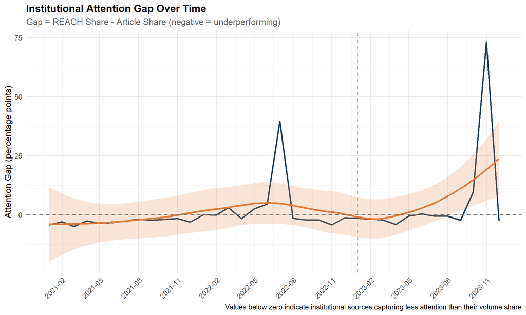

```r
ggplot(monthly_inst, aes(x = date_month, y = Attention_Gap)) +
  geom_line(color = "#1a3c5a", linewidth = 1) +
  geom_smooth(method = "loess", se = TRUE, color = "#e07b39", fill = "#e07b39", alpha = 0.2) +
  geom_hline(yintercept = 0, linetype = "dashed", color = "gray50") +
  geom_vline(xintercept = as.Date("2023-01-01"), linetype = "dashed", color = "#27ae60") +
  scale_x_date(date_labels = "%Y-%m", date_breaks = "3 months") +
  labs(
    title = "Institutional Attention Gap Over Time",
    subtitle = "Gap = REACH Share - Article Share (negative = underperforming)",
    x = NULL,
    y = "Attention Gap (percentage points)",
    caption = "Values below zero indicate institutional sources capturing less attention than their volume share"
  ) +
  theme(axis.text.x = element_text(angle = 45, hjust = 1))
```

# 5 Analysis 5.4: Period Comparison (Structural Break Test)

## 5.1 ERM II vs Euro Era Attention Gap

```r
period_inst <- hnb[, .(
  Articles = .N,
  Total_REACH = sum(REACH, na.rm = TRUE),
  Inst_Articles = sum(INSTITUTIONAL),
  Inst_REACH = sum(REACH[INSTITUTIONAL], na.rm = TRUE),
  HNB_Articles = sum(ACTOR_TYPE == "HNB Official"),
  HNB_REACH = sum(REACH[ACTOR_TYPE == "HNB Official"], na.rm = TRUE)
), by = period]

period_inst[, `:=`(
  Inst_Article_Share = Inst_Articles / Articles * 100,
  Inst_REACH_Share = Inst_REACH / Total_REACH * 100,
  HNB_Article_Share = HNB_Articles / Articles * 100,
  HNB_REACH_Share = HNB_REACH / Total_REACH * 100
)]

period_inst[, `:=`(
  Inst_Gap = Inst_REACH_Share - Inst_Article_Share,
  HNB_Gap = HNB_REACH_Share - HNB_Article_Share
)]

period_inst %>%
  mutate(
    Articles = format(Articles, big.mark = ","),
    Inst_Articles = format(Inst_Articles, big.mark = ","),
    Inst_Article_Share = sprintf("%.1f%%", Inst_Article_Share),
    Inst_REACH_Share = sprintf("%.1f%%", Inst_REACH_Share),
    Inst_Gap = sprintf("%+.1f pp", Inst_Gap),
    HNB_Article_Share = sprintf("%.2f%%", HNB_Article_Share),
    HNB_REACH_Share = sprintf("%.2f%%", HNB_REACH_Share),
    HNB_Gap = sprintf("%+.2f pp", HNB_Gap)
  ) %>%
  select(period, Articles, Inst_Article_Share, Inst_REACH_Share, Inst_Gap,
         HNB_Article_Share, HNB_REACH_Share, HNB_Gap) %>%
  kable(col.names = c("Period", "Total Articles", "Inst. Article %", "Inst. REACH %",
                      "Inst. Gap", "HNB Article %", "HNB REACH %", "HNB Gap")) %>%
  kable_styling(bootstrap_options = c("striped", "hover"), full_width = FALSE)
```

| Period | Total Articles | Inst. Article % | Inst. REACH % | Inst. Gap | HNB Article % | HNB REACH % | HNB Gap |
| --- | --- | --- | --- | --- | --- | --- | --- |
| ERM II | 13,668 | 4.6% | 7.1% | +2.5 pp | 2.09% | 1.11% | -0.98 pp |
| Euro Era | 5,460 | 4.7% | 15.3% | +10.6 pp | 2.38% | 1.00% | -1.38 pp |

## 5.2 Period Comparison Visualization

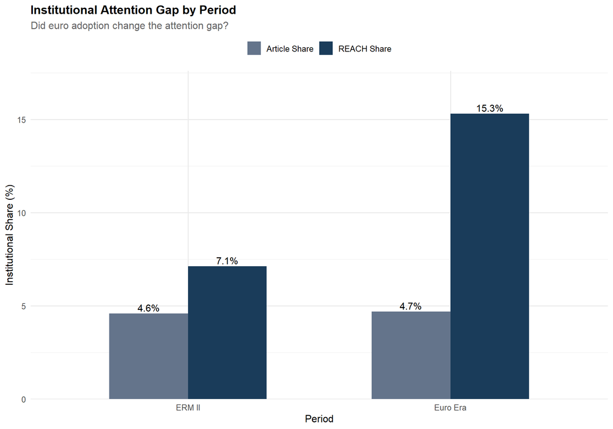

```r
period_gap_long <- period_inst %>%
  select(period, Inst_Article_Share, Inst_REACH_Share) %>%
  pivot_longer(cols = -period, names_to = "Metric", values_to = "Percentage") %>%
  mutate(Metric = ifelse(Metric == "Inst_Article_Share", "Article Share", "REACH Share"))

ggplot(period_gap_long, aes(x = period, y = Percentage, fill = Metric)) +
  geom_col(position = "dodge", width = 0.6) +
  geom_text(aes(label = sprintf("%.1f%%", Percentage)),
            position = position_dodge(width = 0.6), vjust = -0.3, size = 4) +
  scale_fill_manual(values = c("Article Share" = "#64748b", "REACH Share" = "#1a3c5a")) +
  scale_y_continuous(expand = expansion(mult = c(0, 0.15))) +
  labs(
    title = "Institutional Attention Gap by Period",
    subtitle = "Did euro adoption change the attention gap?",
    x = "Period",
    y = "Institutional Share (%)",
    fill = NULL
  ) +
  theme(legend.position = "top")
```

# 6 Analysis 5.5: Source-Level Analysis

## 6.1 Top Sources: Institutional vs Media

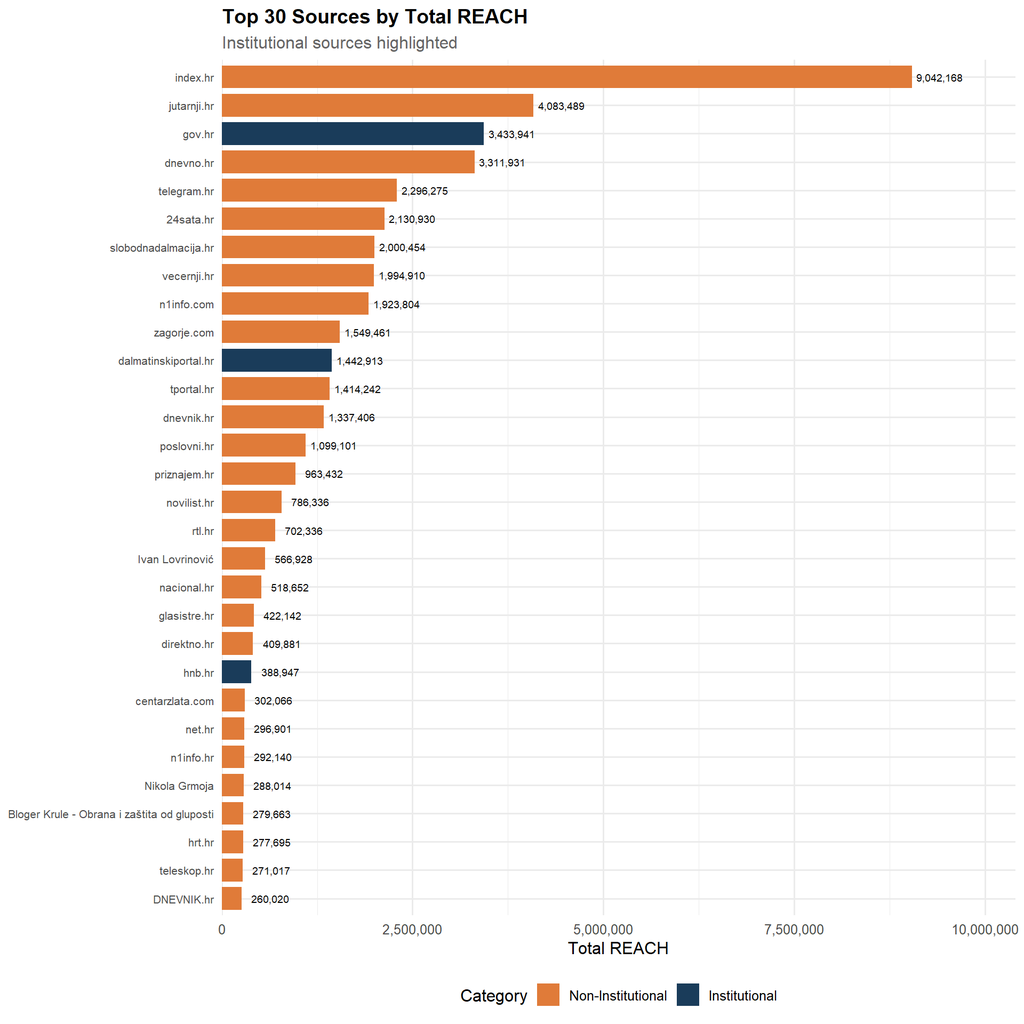

```r
source_summary <- hnb[, .(
  Articles = .N,
  Total_REACH = sum(REACH, na.rm = TRUE),
  Mean_REACH = mean(REACH, na.rm = TRUE),
  ACTOR_TYPE = first(ACTOR_TYPE),
  Institutional = first(INSTITUTIONAL)
), by = FROM][order(-Total_REACH)]

# Top 30 sources
top_sources <- source_summary[1:30]

ggplot(top_sources, aes(x = reorder(FROM, Total_REACH), y = Total_REACH, fill = Institutional)) +
  geom_col(width = 0.8) +
  geom_text(aes(label = format(Total_REACH, big.mark = ",")), hjust = -0.1, size = 2.5) +
  coord_flip() +
  scale_fill_manual(values = c("TRUE" = "#1a3c5a", "FALSE" = "#e07b39"),
                    labels = c("TRUE" = "Institutional", "FALSE" = "Non-Institutional")) +
  scale_y_continuous(labels = comma, expand = expansion(mult = c(0, 0.15))) +
  labs(
    title = "Top 30 Sources by Total REACH",
    subtitle = "Institutional sources highlighted",
    x = NULL,
    y = "Total REACH",
    fill = "Category"
  ) +
  theme(axis.text.y = element_text(size = 8))
```

## 6.2 Efficiency by Source (High-Volume Sources)

```r
# Sources with minimum 50 articles
source_efficiency <- source_summary[Articles >= 50]
source_efficiency[, `:=`(
  Article_Share = Articles / sum(hnb$Articles) * 100,
  REACH_Share = Total_REACH / sum(hnb$REACH, na.rm = TRUE) * 100
)]
source_efficiency[, Efficiency := REACH_Share / Article_Share]

# Top institutional sources by efficiency
inst_sources <- source_efficiency[Institutional == TRUE][order(-Efficiency)][1:15]

inst_sources %>%
  mutate(
    Articles = format(Articles, big.mark = ","),
    Total_REACH = format(Total_REACH, big.mark = ","),
    Mean_REACH = format(round(Mean_REACH, 0), big.mark = ","),
    Article_Share = sprintf("%.2f%%", Article_Share),
    REACH_Share = sprintf("%.2f%%", REACH_Share),
    Efficiency = sprintf("%.2fx", Efficiency)
  ) %>%
  select(FROM, ACTOR_TYPE, Articles, Article_Share, REACH_Share, Efficiency, Mean_REACH) %>%
  kable(col.names = c("Source", "Actor Type", "Articles", "Article %", "REACH %",
                      "Efficiency", "Mean REACH"),
        caption = "Top 15 Institutional Sources by Efficiency (min. 50 articles)") %>%
  kable_styling(bootstrap_options = c("striped", "hover"), full_width = FALSE) %>%
  scroll_box(height = "400px")
```

Top 15 Institutional Sources by Efficiency (min. 50 articles)

[output not shown]

# 7 Analysis 5.6: Media Amplification Effect

## 7.1 Who Amplifies HNB Communication?

When HNB publishes official communication, which media sources amplify it and capture the subsequent attention?

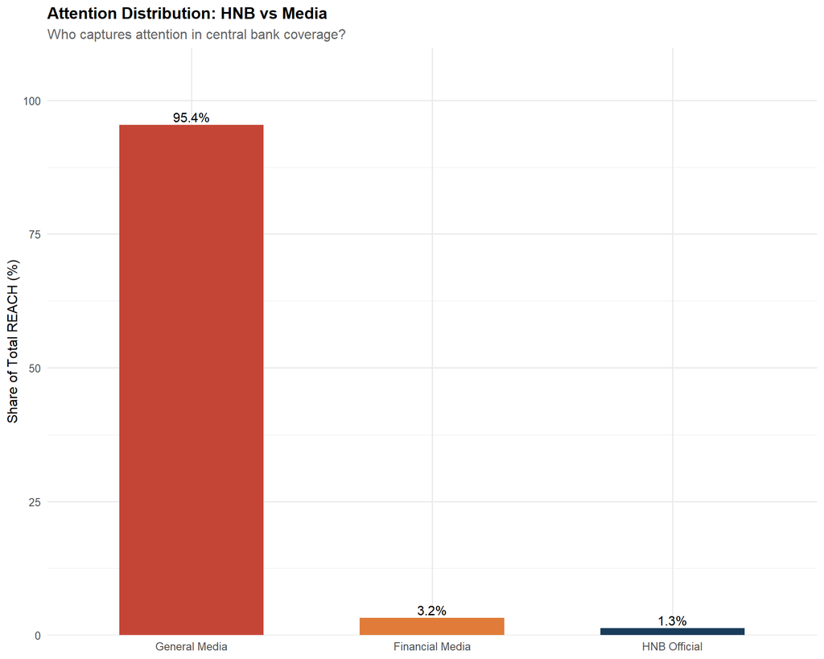

```r
# Calculate media "amplification" by looking at actor type attention capture
media_actors <- c("Financial Media", "General Media")

media_amplification <- hnb[ACTOR_TYPE %in% media_actors, .(
  Articles = .N,
  Total_REACH = sum(REACH, na.rm = TRUE),
  Mean_REACH = mean(REACH, na.rm = TRUE)
), by = ACTOR_TYPE]

# Compare to HNB Official
hnb_comparison <- hnb[ACTOR_TYPE %in% c("HNB Official", media_actors), .(
  Articles = .N,
  Total_REACH = sum(REACH, na.rm = TRUE),
  Mean_REACH = mean(REACH, na.rm = TRUE)
), by = ACTOR_TYPE]

hnb_comparison[, `:=`(
  Article_Share = Articles / sum(Articles) * 100,
  REACH_Share = Total_REACH / sum(Total_REACH) * 100
)]

ggplot(hnb_comparison, aes(x = reorder(ACTOR_TYPE, -REACH_Share), y = REACH_Share, fill = ACTOR_TYPE)) +
  geom_col(width = 0.6) +
  geom_text(aes(label = sprintf("%.1f%%", REACH_Share)), vjust = -0.3, size = 4) +
  scale_fill_manual(values = c("HNB Official" = "#1a3c5a",
                               "Financial Media" = "#e07b39",
                               "General Media" = "#c44536")) +
  scale_y_continuous(expand = expansion(mult = c(0, 0.15))) +
  labs(
    title = "Attention Distribution: HNB vs Media",
    subtitle = "Who captures attention in central bank coverage?",
    x = NULL,
    y = "Share of Total REACH (%)",
    fill = "Actor Type"
  ) +
  theme(legend.position = "none")
```

## 7.2 Media Intermediation Ratio

```r
# Calculate intermediation ratio
hnb_reach <- sum(hnb[ACTOR_TYPE == "HNB Official", REACH], na.rm = TRUE)
media_reach <- sum(hnb[ACTOR_TYPE %in% media_actors, REACH], na.rm = TRUE)
total_reach <- sum(hnb$REACH, na.rm = TRUE)

intermediation_ratio <- media_reach / hnb_reach

cat("Media Intermediation Analysis\n")
```

```
Media Intermediation Analysis
```

```r
cat("=============================\n")
cat("HNB Official REACH:", format(hnb_reach, big.mark = ","), "\n")
```

```
HNB Official REACH: 567,340
```

```r
cat("Media (Financial + General) REACH:", format(media_reach, big.mark = ","), "\n")
```

```
Media (Financial + General) REACH: 42,309,608
```

```r
cat("\nIntermediation Ratio:", round(intermediation_ratio, 1), "x\n")
```

```
Intermediation Ratio: 74.6 x
```

```r
cat("(Media captures", round(intermediation_ratio, 1), "times more attention than HNB Official)\n")
```

```
(Media captures 74.6 times more attention than HNB Official)
```

```r
cat("\nShare of total attention:\n")
```

```
Share of total attention:
```

```r
cat("  HNB Official:", sprintf("%.1f%%", hnb_reach / total_reach * 100), "\n")
```

```
  HNB Official: 1.1%
```

```r
cat("  Financial Media:", sprintf("%.1f%%", sum(hnb[ACTOR_TYPE == "Financial Media", REACH], na.rm = TRUE) / total_reach * 100), "\n")
```

```
  Financial Media: 2.7%
```

```r
cat("  General Media:", sprintf("%.1f%%", sum(hnb[ACTOR_TYPE == "General Media", REACH], na.rm = TRUE) / total_reach * 100), "\n")
```

```
  General Media: 78.2%
```

# 8 Summary and Key Findings

## 8.1 Core Hypothesis Test

```r
# Extract key metrics
inst_gap <- inst_summary[INST_CATEGORY == "Institutional", Attention_Gap]
inst_efficiency <- inst_summary[INST_CATEGORY == "Institutional", Efficiency]
hnb_gap <- actor_summary[ACTOR_TYPE == "HNB Official", Attention_Gap]
hnb_efficiency <- actor_summary[ACTOR_TYPE == "HNB Official", Efficiency]

tibble(
  Metric = c(
    "H2: Institutional Attention Gap",
    "Institutional Efficiency",
    "HNB Official Attention Gap",
    "HNB Official Efficiency",
    "Media Intermediation Ratio",
    "Statistical Significance (Wilcoxon p-value)"
  ),
  Value = c(
    sprintf("%+.1f percentage points", inst_gap),
    sprintf("%.2fx", inst_efficiency),
    sprintf("%+.1f percentage points", hnb_gap),
    sprintf("%.2fx", hnb_efficiency),
    sprintf("%.1fx", intermediation_ratio),
    format.pval(wilcox_result$p.value, digits = 3)
  ),
  Interpretation = c(
    ifelse(inst_gap < 0, "Institutional sources UNDERPERFORM", "Institutional sources overperform"),
    ifelse(inst_efficiency < 1, "Below proportional attention", "Above proportional attention"),
    ifelse(hnb_gap < 0, "HNB Official UNDERPERFORMS", "HNB Official overperforms"),
    ifelse(hnb_efficiency < 1, "Below proportional attention", "Above proportional attention"),
    "Media captures X times more attention than HNB",
    ifelse(wilcox_result$p.value < 0.05, "Statistically significant difference", "Not significant")
  )
) %>%
  kable(col.names = c("Metric", "Value", "Interpretation")) %>%
  kable_styling(bootstrap_options = c("striped", "hover"), full_width = FALSE)
```

[output not shown]

## 8.3 Policy Implications for HNB

Based on the attention gap analysis:

1. **Direct communication limitations:** With efficiency below 1.0, increasing article volume alone will not proportionally increase attention
2. **Strategic media relations:** Given media intermediation dominance, optimizing relationships with high-reach media sources may be more effective than direct publication
3. **Content strategy:** Analyzing which specific HNB communications achieve higher efficiency can inform content optimization
4. **Layered communication:** Following ECB best practices, simplified versions for general audiences may improve attention capture

# 9 Appendix: Technical Notes

## 9.1 Attention Gap Calculation

$$\text{Attention Gap} = \text{REACH Share} - \text{Article Share}$$

- Negative values indicate the source captures less attention than its volume share
- Zero indicates proportional attention
- Positive values indicate attention amplification

## 9.2 Efficiency Index

$$\text{Efficiency} = \frac{\text{REACH Share}}{\text{Article Share}}$$

- Values below 1.0 indicate underperformance
- Values equal to 1.0 indicate proportional attention
- Values above 1.0 indicate overperformance

## 9.3 Institutional Classification

Institutional sources include: - HNB Official (hnb.hr, Hrvatska narodna banka) - Financial Regulators (HANFA, FINA) - Government (gov.hr, ministries)

All other sources are classified as non-institutional.